# Probability of cetacean species occurence

Lory Salazar

2/24/2021

```r
# Read in the data
ca_cetaceans <- list.files(path = here("data", "ca_cetaceans"), pattern = "*.tif", full.names = TRUE)

ca_raster <- raster::stack(ca_cetaceans)
```

### Visualizing cetacean richness in California

Using the California cetacean species data from AquaMaps, we look at the probability of occurrence of cetacean species in the California Bight. We set a probability threshold based off of the probability of occurrence, and use this to determine what the richness of cetacean species off the coast of California is.

```r
# download coastline
coastline110 <- ne_download(scale = 110, type = 'coastline', category = 'physical', returnclass = "sf")

# download states
states110 <- ne_download(scale = 110, type = 'states', category = 'cultural', returnclass = "sf") %>%
  filter(name == "California")
```

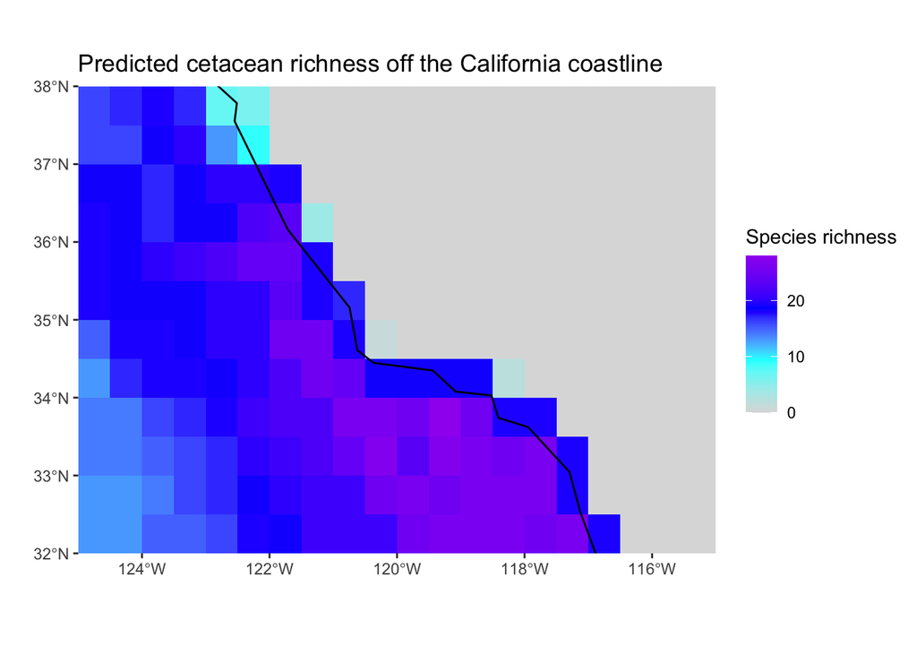

```r
# Creating a function to set our probability threshold
cetaceans_fun <- function(x, thresh = .6) {
  y <- ifelse(x >= thresh, 1, NA)
  return(y)
}

# Creating the calculation that we will use to create our dataframe
cetaceans <- calc(ca_raster, fun = cetaceans_fun)
cetaceans_calc <- calc(cetaceans, fun = sum, na.rm = TRUE)

# Converting to a dataframe so that we can use ggplot
cetaceans_df <- raster::rasterToPoints(cetaceans_calc) %>%
  as.data.frame()

# Plot to show the cetaceans for the coastline
ggplot() +
  geom_raster(data = cetaceans_df, aes(x = x, y = y, fill = layer)) +
  geom_sf(data = coastline110) +
  coord_sf(expand = 0, xlim = c(-125,-115), ylim = c(32,38)) +
  scale_fill_gradientn(colors = c("gainsboro","cyan","blue","purple")) +
  labs(x = " ", y = " ",
       fill = "Species richness",
       title = "Predicted cetacean richness off the California coastline")
```

**Figure 1.** The map displays the Southern California Bight, the 426-mile stretch of coastline along the West Coast of the United States. Purple, blue, cyan, and gray colors indicate the species richness of 35 cetacean species along the coast, with purple indicated a that the species is highly present, and gray indicating absence of species. The presence of a species was determined using a probability threshold of 0.6, wherein a species is considered to be present if the probability is above 0.6.

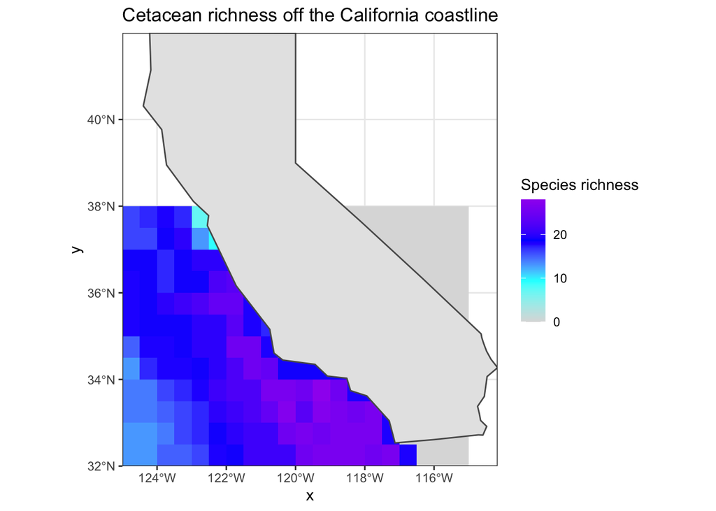

```r
# Plot to show cetaceans for the state of CA; not necessary, but helped me to better understand where we were looking.
ggplot() +
  geom_raster(data = cetaceans_df, aes(x = x, y = y, fill = layer)) +
  geom_sf(data = states110) +
  coord_sf(expand = 0) +
  scale_fill_gradientn(colors = c("gainsboro","cyan","blue","purple")) +
  labs(fill = "Species richness",
       title = "Cetacean richness off the California coastline") +
  theme_bw()
```

**Figure 2.** The map displays the species richness of cetaceans as seen in **Figure 1**, but gives a look at the entirety of California. Purple, blue, cyan, and gray colors indicate the species richness of 35 cetacean species along the coast.